# Programação em R

Para avançar nos estudos em R, devemos aprender como construir funções e loops. Essas ferramentas acabam sendo um dos grandes diferenciais do R em relação a outras ferramentas como SPSS e Excel, umas vez que permitem a produção de análises automatizadas e aumentam a replicabilidade do código.

# Funções em R

Uma das melhores funcionalidades do R é a possibilidade de construção de funções e consequente automatização de processos. Por ser uma linguagem de programação, o R possibilita o desenvolvimento de códigos e comandos que podem ser aplicados a diferentes contextos, reduzindo o trabalho de um analista que precisa executar o mesmo trabalho diversas vezes. Começando simples, vamos desenvolver nossa primeira função, a `media()`.

```r
# criar funcao de media (soma dos valores divido pelo numero de casos)

media <- function(x){

  media = sum(x) / length(x)

  return(media)
}
```

```r
# testar funcao
exemplo <- c(10, 1, 26, 34)
media(exemplo)
```

```
[1] 17.75
```

```r
mean(exemplo)
```

```
[1] 17.75
```

Uma função mais elaborada pode replicar um tipo de processamento ou visualização de dados. Vejamos o exemplo abaixo, no qual temos um gráfico scatter plot que pode ser executado entre diferentes variáveis do banco de dados Pokemon.

```r
# ler dados
fulldata <- read.csv('https://raw.githubusercontent.com/claudioalvesmonteiro/nice-data-repo/master/data/Pokemon.csv')

# filtrar tipos
fulldata = fulldata[(fulldata$Type1 == 'Grass') | (fulldata$Type1 == 'Fire') | (fulldata$Type1 == 'Water'),]

# selecionar 20 primeiros para visualizar
data = fulldata[1:20,]
```

[figure not shown]

```r
ggplot(data, aes(x = Attack, y = Defense)) +
  geom_point()+
  geom_smooth(method=lm,se=FALSE)+
  geom_text_repel(aes(label = Name), size = 4)+
  theme_classic()+
  labs(y = "Ataque", x="Defesa")+
  theme(axis.text=element_text(size=12),axis.title=element_text(size=14,face="bold"))
```

Agora vamos definir uma função para executar o gráfico acima e que pode ser replicada para qualquer par de variáveis numéricas na base de dados.

```r
scatterFun <- function(data, xaxis, yaxis, xname, yname){

  plot <- ggplot(data, aes(x = xaxis, y = yaxis)) +
          geom_point()+
          geom_smooth(method = lm, se = FALSE)+
          geom_text_repel(aes(label = Name), size = 4)+
          theme_classic()+
          labs(x = xname, y = yname)+
          theme(axis.text = element_text(size=12), axis.title = element_text(size = 14, face = "bold"))

  return(plot)
}
```

Agora vamos executar o gráfico de maneira bem mais simples, para qualquer par de variáveis numéricas:

[figure not shown]

```r
scatterFun(data, data$Attack, data$Defense, 'Ataque', 'Defesa')
```

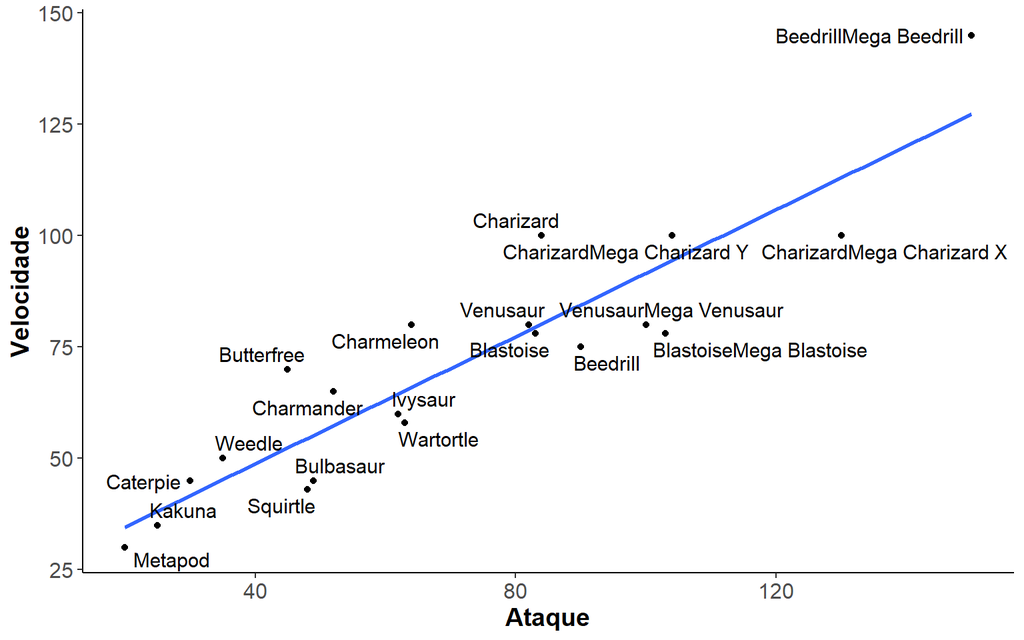

```r
scatterFun(data, data$Attack, data$Speed, 'Ataque', 'Velocidade')
```

## Praticar

Agora é com você! Para praticar, crie uma função que retorna um gráfico histograma para analisar a distribuição de qualquer variável númerica entre as classes Type1 do dataset.

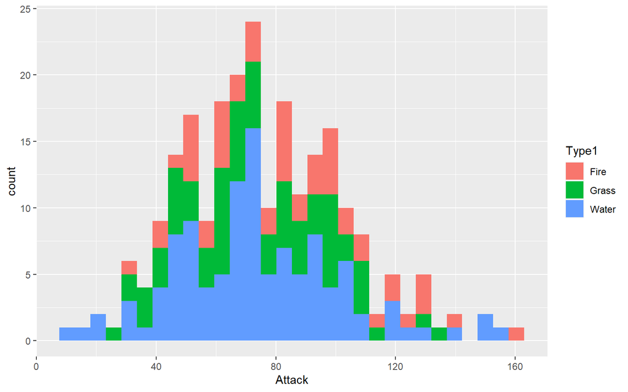

```r
ggplot(fulldata, aes(x=Attack, fill=Type1))+
  geom_histogram()
```

# Condicionais If/Else

```r
numero = -10

if (numero > 0){

  print('número é positivo')

} else {

  print('número é negativo')

}
```

```
[1] "número é negativo"
```

Podemos ainda aplicar uma condição dentro de uma função. Vamos usar a função acima para colcoar uma condição para mostrar ou não os nomes dos pokemons no gráfico.

```r
scatterFun2 <- function(data, xaxis, yaxis, xname, yname, showname=TRUE){

  plot <- ggplot(data, aes(x = xaxis, y = yaxis)) +
          geom_point()+
          geom_smooth(method = lm, se = FALSE)+
          theme_classic()+
          labs(x = xname, y = yname)+
          theme(axis.text = element_text(size=12), axis.title = element_text(size = 14, face = "bold"))

  if (showname == TRUE){

    plot <- plot + geom_text_repel(aes(label = Name), size = 4)

    }

  return(plot)
}
```

[figure not shown]

```r
scatterFun2(data, data$Attack, data$Speed, 'Ataque', 'Velocidade', showname = FALSE)
```

# Loops

Loops são uteis para reproduzir uma mesma tarefa para diferentes objetos ou executar uma sequência de processamentos. Pode ser aplicado a uma situação na qual você quer gerar vários gráficos do mesmo tipo com diferentes variáveis, por exemplo.

O loop *For* é utilizado para mapear uma lista de objetos e executar alguma tarefa com cada objeto. Abaixo segue um exemplo simples, em que passamos uma lista de nomes para que sejam printados no console.

```r
# FOR
nomes <- c('José', 'Maria', 'Francisco')

for (nome in nomes){

  print(nome)

}
```

```
[1] "José"
[1] "Maria"
[1] "Francisco"
```

O loop *While* é utilizado quando você quer executar um processamento, porém colocando uma condição de parada. Abaixo segue um exemplo em que o objeto *cont* é iniciado em zero e a cada laço do while é adicionado 1 a *cont* e o valor é mostrado no console.

```r
# WHILE
cont <- 0

while (cont < 5){

  print(cont)
  cont = cont + 1

}
```

```
[1] 0
[1] 1
[1] 2
[1] 3
[1] 4
```

## Praticar

Crie um loop para mostrar no console a raiz quadrada de cada número na lista abaixo.

```r
lista <- c(4, 16, 8, 27, 127)
```

# Combinando Funções e Loops

Para desfrutar de todo o poder dessas ferramentas computacionais agora vamos combinar a utilização de loops e funções. Como exemplo vamos reutilizar o dataset Pokemon para desenvolver um loop que vai criar e salvar gráficos scatter plot entre diferentes variáveis do dataset.

```r
# criando a funcao
scatterFun3 <- function(data, var){

  plot <- ggplot(data, aes(x = data[,'Total'], y = data[,var])) +
          geom_point()+
          geom_smooth(method = lm, se = FALSE)+
          theme_classic()+
          labs(x = 'Total', y = var)+
          theme(axis.text = element_text(size=12), axis.title = element_text(size = 14, face = "bold"))

  return(plot)
}
```

```r
# lista de variaveis
vars <- c('Attack', 'Defense', 'Sp_Atk', 'Sp_Def', 'Speed', 'HP')

# agora vamos criar e salvar diferentes graficos entre 'Total' e cada variavel dentro de vars
for (var in vars){

  # gera grafico
  plot <- scatterFun3(data, var)

  # gera nome para salvar e printa nome
  nome_para_salvar = paste0('graficos/Total_', var, '_scatter_plot.png')

  # salvar grafico localmente
  ggsave(nome_para_salvar, plot, width = 5, height = 4)

}
```

# Dicas extras

1. Não usar caracteres como acentos no meio do código
2. Criar um projeto no RStudio em vez de usar o setwd()
3. Versionar o código no Github
4. Estruturar comentarios como no exemplo abaixo

```r
#======================
# pre-processamneto
#=====================

# removendo casos faltantes

# visualizar distribuicao da variavel X

#======================
# modelos
#=====================

# modelo 1 - descricao breve

# modelo 2 - descricao breve
```